# Linear Regression Analysis of the Bike Dataset

Tessa Liew Lee Yi

9/11/2021

## Seoul Bike Rent Counts by Day

# Overview on the Seoul Bike Dataset

Objective: i. Determine what is the relationship between the number of bikes rented with each of the predictor variables ii. fit a model to predict the rent count for the next financial period.

```
##   X       date season    holiday snowfall rainfall rent_count temperature
## 1 1 2017-12-01 Winter No Holiday        0      0.0       9539       -1.10
## 2 2 2017-12-02 Winter No Holiday        0      0.0       8523        2.70
## 3 3 2017-12-03 Winter No Holiday        0      4.0       7222        4.35
## 4 4 2017-12-04 Winter No Holiday        0      0.1       8729       -0.25
## 5 5 2017-12-05 Winter No Holiday        0      0.0       8307       -3.80
## 6 6 2017-12-06 Winter No Holiday       86      1.3       6669        1.15
##   humidity wind_speed visibility dewpoint_temp solar_radiation rep_count
## 1     37.5       1.40      20000        -17.40               0       732
## 2     55.5       1.60      14410         -5.55               0       758
## 3     84.5       1.60       3380          2.65               0       716
## 4     43.5       3.60      19130        -12.95               0       629
## 5     34.5       0.00      20000        -17.70               0       577
## 6     76.5       0.55      13965         -6.30               0       707
##   rep_count_smooth
## 1         732.0000
## 2         750.2000
## 3         726.2600
## 4         658.1780
## 5         601.3534
## 6         675.3060
```

From the correlation plot, we can see that temperature is highly positively correlated to dewpoint_temp and solar_radiation and negatively correlated to wind_speed. Besides that, we can see that dewpoint_temp is highly correlated to humidity and solar_radiation. Also, humidity and visibility are highly negatively correlated. From these observations, we can add interaction terms in out fitted model to improve the fit.

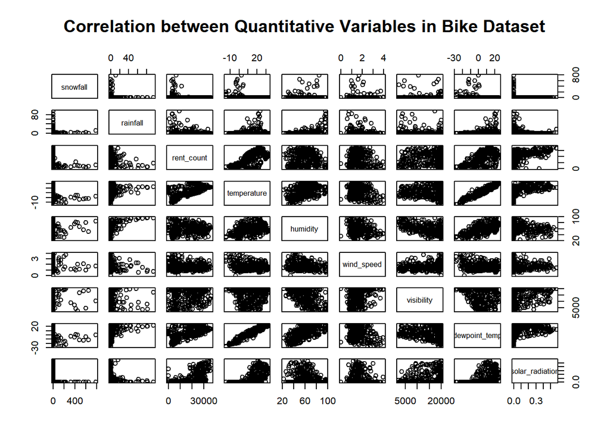

```
##                    snowfall    rainfall rent_count temperature    humidity
## snowfall         1.00000000 -0.02249252 -0.2408360 -0.26854946  0.08361124
## rainfall        -0.02249252  1.00000000 -0.2142524  0.14212863  0.52101828
## rent_count      -0.24083601 -0.21425244  1.0000000  0.69620701  0.01287760
## temperature     -0.26854946  0.14212863  0.6962070  1.00000000  0.38423590
## humidity         0.08361124  0.52101828  0.0128776  0.38423590  1.00000000
## wind_speed       0.01399372 -0.09440167 -0.1680027 -0.24947710 -0.20537057
## visibility      -0.08228803 -0.20134064  0.1492139  0.02276389 -0.53094471
## dewpoint_temp   -0.20566149  0.25923897  0.5985892  0.95629365  0.61868031
## solar_radiation -0.14619672 -0.13090376  0.6400973  0.62350214 -0.04182947
##                  wind_speed  visibility dewpoint_temp solar_radiation
## snowfall         0.01399372 -0.08228803    -0.2056615     -0.14619672
## rainfall        -0.09440167 -0.20134064     0.2592390     -0.13090376
## rent_count      -0.16800273  0.14921385     0.5985892      0.64009729
## temperature     -0.24947710  0.02276389     0.9562936      0.62350214
## humidity        -0.20537057 -0.53094471     0.6186803     -0.04182947
## wind_speed       1.00000000  0.21261590    -0.2593501     -0.01579240
## visibility       0.21261590  1.00000000    -0.1411805      0.10889421
## dewpoint_temp   -0.25935009 -0.14118047     1.0000000      0.52045843
## solar_radiation -0.01579240  0.10889421     0.5204584      1.00000000
```

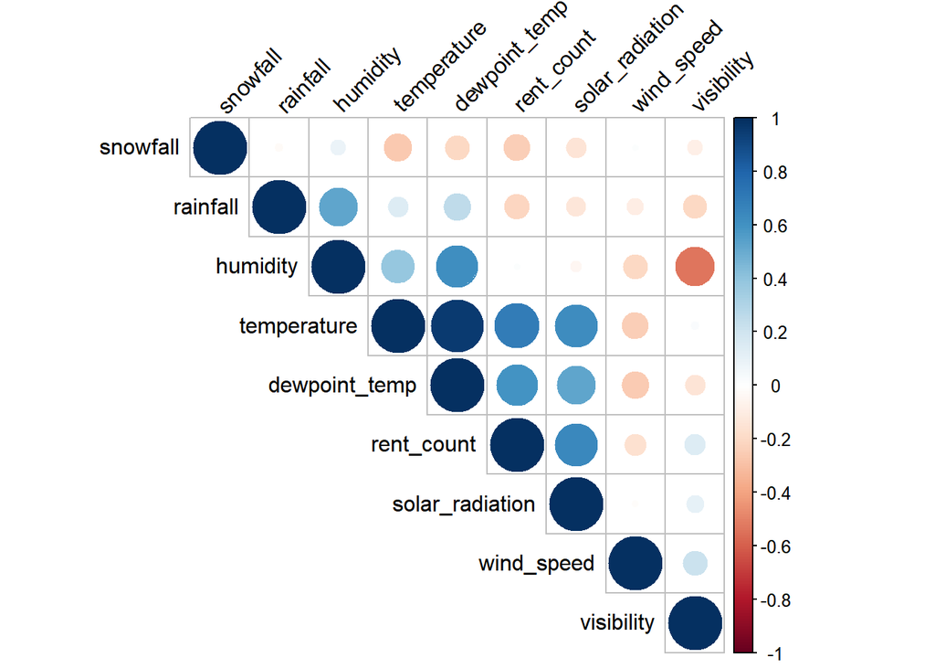

#Splitting the data into training and test data

```r
set.seed(43)
train <- sample(1:353, 285)

bike_train <- seoul_bike[train,]

bike_test <- seoul_bike[-train,]
```

Fitting linear regression models Model 1: Full model observation: Many insignificant variables Adjusted R-squared value is relatively high. However, unreliable because of multicolinearity From the regression analysis, we can see that the linearity assumption and constant variance assumption have been violated. Therefore, we perform transformation on the response and fit a new model. Also, we add interaction terms and use mixed step-wise selection for variable selection.

```
##
## Call:
## lm(formula = rent_count ~ ., data = bike_train)
##
## Residuals:
##    Min     1Q Median     3Q    Max
## -13820  -2228    214   2522  10684
##
## Coefficients:
##                     Estimate Std. Error t value Pr(>|t|)
## (Intercept)        2.155e+04  4.903e+03   4.395 1.59e-05 ***
## seasonSpring      -7.003e+03  8.664e+02  -8.082 2.09e-14 ***
## seasonSummer      -7.523e+03  1.070e+03  -7.033 1.64e-11 ***
## seasonWinter      -1.170e+04  1.062e+03 -11.021  < 2e-16 ***
## holidayNo Holiday  2.634e+03  1.203e+03   2.189   0.0295 *
## snowfall          -5.249e+00  2.815e+00  -1.865   0.0633 .
## rainfall          -1.676e+02  2.451e+01  -6.835 5.38e-11 ***
## temperature        2.086e+02  1.837e+02   1.135   0.2573
## humidity          -7.068e+01  5.294e+01  -1.335   0.1830
## wind_speed        -4.752e+02  4.124e+02  -1.152   0.2502
## visibility        -1.320e-02  6.030e-02  -0.219   0.8269
## dewpoint_temp      1.064e+02  1.875e+02   0.568   0.5707
## solar_radiation    2.534e+04  2.739e+03   9.251  < 2e-16 ***
## ---
## Signif. codes:  0 '***' 0.001 '**' 0.01 '*' 0.05 '.' 0.1 ' ' 1
##
## Residual standard error: 4140 on 272 degrees of freedom
## Multiple R-squared:  0.8348, Adjusted R-squared:  0.8275
## F-statistic: 114.6 on 12 and 272 DF,  p-value: < 2.2e-16
```

```
## Analysis of Variance Table
##
## Response: rent_count
##                  Df     Sum Sq    Mean Sq  F value    Pr(>F)
## season            3 1.6366e+10 5455220533 318.2163 < 2.2e-16 ***
## holiday           1 7.0168e+07   70168181   4.0931  0.044037 *
## snowfall          1 2.2236e+08  222363753  12.9710  0.000376 ***
## rainfall          1 3.3502e+09 3350227785 195.4269 < 2.2e-16 ***
## temperature       1 1.6150e+09 1614974751  94.2054 < 2.2e-16 ***
## humidity          1 4.5747e+08  457470833  26.6854 4.636e-07 ***
## wind_speed        1 8.5773e+06    8577251   0.5003  0.479960
## visibility        1 5.5545e+06    5554461   0.3240  0.569680
## dewpoint_temp     1 3.0377e+06    3037721   0.1772  0.674125
## solar_radiation   1 1.4670e+09 1466993860  85.5733 < 2.2e-16 ***
## Residuals       272 4.6629e+09   17143121
## ---
## Signif. codes:  0 '***' 0.001 '**' 0.01 '*' 0.05 '.' 0.1 ' ' 1
```

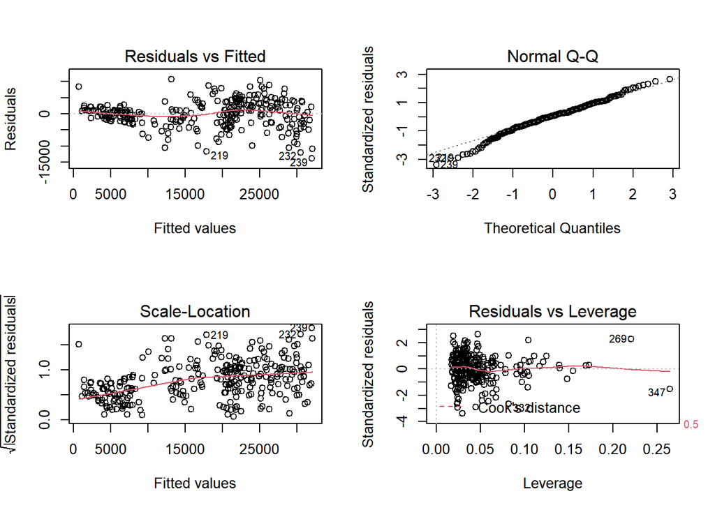

# Transformation of Response using Boxcox Method

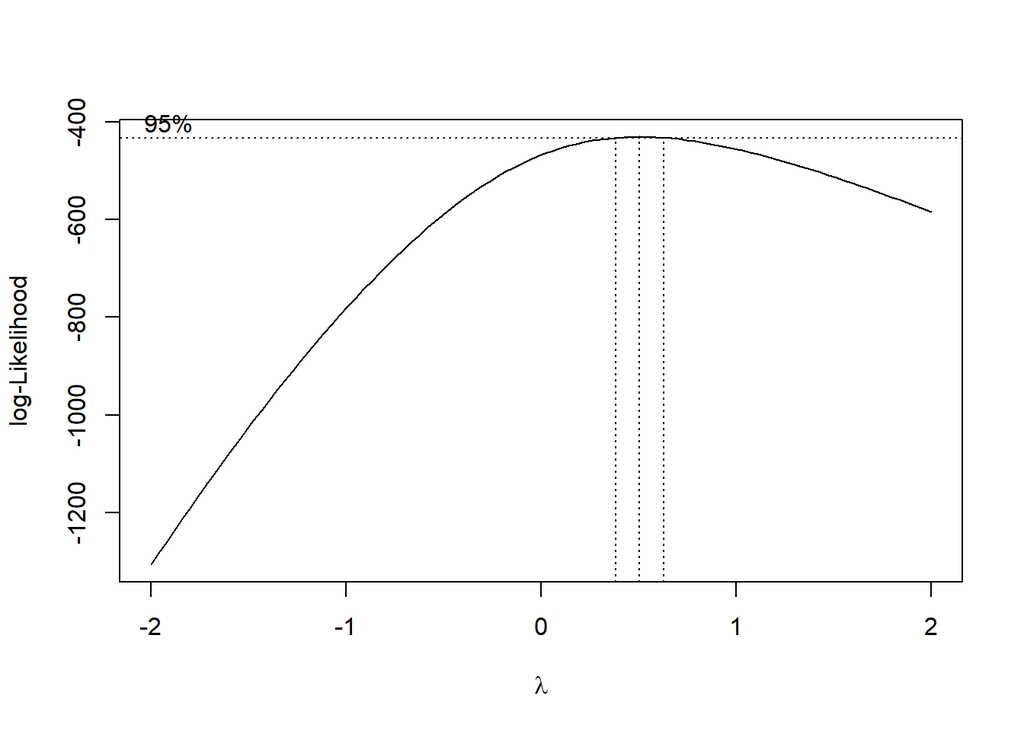

# Adding in the interaction terms for suspected multicolinearity and perform Variable Selection

## Final Training Model: Model_11

```r
model_11 <- lm(formula = log(rent_count) ~ humidity + solar_radiation + rainfall +
    snowfall + season + holiday + wind_speed + dewpoint_temp +
    solar_radiation:dewpoint_temp, data = bike_train)

summary(model_11)
```

```
##
## Call:
## lm(formula = log(rent_count) ~ humidity + solar_radiation + rainfall +
##     snowfall + season + holiday + wind_speed + dewpoint_temp +
##     solar_radiation:dewpoint_temp, data = bike_train)
##
## Residuals:
##      Min       1Q   Median       3Q      Max
## -1.41262 -0.13093  0.02611  0.17857  1.10272
##
## Coefficients:
##                                 Estimate Std. Error t value Pr(>|t|)
## (Intercept)                   10.2603248  0.1413452  72.591  < 2e-16 ***
## humidity                      -0.0099584  0.0020631  -4.827 2.31e-06 ***
## solar_radiation                2.2050380  0.2850135   7.737 1.98e-13 ***
## rainfall                      -0.0206367  0.0017577 -11.741  < 2e-16 ***
## snowfall                      -0.0005792  0.0001994  -2.905 0.003976 **
## seasonSpring                  -0.4823827  0.0604718  -7.977 4.15e-14 ***
## seasonSummer                  -0.2922391  0.0793748  -3.682 0.000279 ***
## seasonWinter                  -0.8935149  0.0736727 -12.128  < 2e-16 ***
## holidayNo Holiday              0.2902772  0.0847522   3.425 0.000709 ***
## wind_speed                    -0.0753821  0.0277784  -2.714 0.007077 **
## dewpoint_temp                  0.0332074  0.0039366   8.435 1.94e-15 ***
## solar_radiation:dewpoint_temp -0.1128587  0.0183951  -6.135 2.98e-09 ***
## ---
## Signif. codes:  0 '***' 0.001 '**' 0.01 '*' 0.05 '.' 0.1 ' ' 1
##
## Residual standard error: 0.2931 on 273 degrees of freedom
## Multiple R-squared:  0.8653, Adjusted R-squared:  0.8599
## F-statistic: 159.5 on 11 and 273 DF,  p-value: < 2.2e-16
```

```r
anova(model_11)
```

```
## Analysis of Variance Table
##
## Response: log(rent_count)
##                                Df Sum Sq Mean Sq  F value    Pr(>F)
## humidity                        1  0.000   0.000   0.0048  0.945038
## solar_radiation                 1 60.552  60.552 705.0371 < 2.2e-16 ***
## rainfall                        1  9.495   9.495 110.5514 < 2.2e-16 ***
## snowfall                        1 10.414  10.414 121.2606 < 2.2e-16 ***
## season                          3 59.700  19.900 231.7080 < 2.2e-16 ***
## holiday                         1  0.625   0.625   7.2830  0.007395 **
## wind_speed                      1  1.528   1.528  17.7861 3.365e-05 ***
## dewpoint_temp                   1  5.103   5.103  59.4229 2.375e-13 ***
## solar_radiation:dewpoint_temp   1  3.233   3.233  37.6414 2.977e-09 ***
## Residuals                     273 23.446   0.086
## ---
## Signif. codes:  0 '***' 0.001 '**' 0.01 '*' 0.05 '.' 0.1 ' ' 1
```

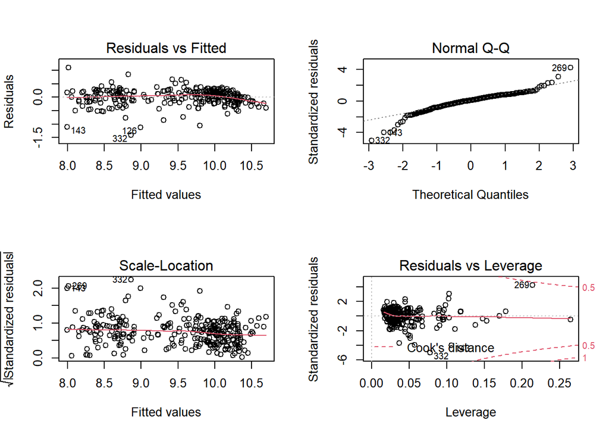

```r
par(mfrow = c(2,2))
plot(model_11)
```

```r
step(model_11, direction = "both")
```

```
## Start:  AIC=-687.87
## log(rent_count) ~ humidity + solar_radiation + rainfall + snowfall +
##     season + holiday + wind_speed + dewpoint_temp + solar_radiation:dewpoint_temp
##
##                                 Df Sum of Sq    RSS     AIC
## <none>                                       23.446 -687.87
## - wind_speed                     1    0.6325 24.079 -682.28
## - snowfall                       1    0.7247 24.171 -681.19
## - holiday                        1    1.0075 24.454 -677.87
## - humidity                       1    2.0010 25.447 -666.52
## - solar_radiation:dewpoint_temp  1    3.2328 26.679 -653.05
## - rainfall                       1   11.8387 35.285 -573.37
## - season                         3   14.6882 38.135 -555.24
```

```
##
## Call:
## lm(formula = log(rent_count) ~ humidity + solar_radiation + rainfall +
##     snowfall + season + holiday + wind_speed + dewpoint_temp +
##     solar_radiation:dewpoint_temp, data = bike_train)
##
## Coefficients:
##                   (Intercept)                       humidity
##                    10.2603248                     -0.0099584
##               solar_radiation                       rainfall
##                     2.2050380                     -0.0206367
##                      snowfall                   seasonSpring
##                    -0.0005792                     -0.4823827
##                  seasonSummer                   seasonWinter
##                    -0.2922391                     -0.8935149
##             holidayNo Holiday                     wind_speed
##                     0.2902772                     -0.0753821
##                 dewpoint_temp  solar_radiation:dewpoint_temp
##                     0.0332074                     -0.1128587
```

## Training Mean Absolute Percentage Error

```r
pred_train <- exp(model_11$fitted.values)
MPE_training<-mean(abs(bike_train$rent_count-pred_train)/bike_train$rent_count)
MPE_training
```

```
## [1] 0.2246249
```

## Final Prediction Model: Model_12

```r
model_12 <- lm(formula = log(rent_count) ~ humidity + solar_radiation + rainfall +
    snowfall + season + holiday + wind_speed + dewpoint_temp +
    solar_radiation:dewpoint_temp, data = bike_test)

summary(model_12)
```

```
##
## Call:
## lm(formula = log(rent_count) ~ humidity + solar_radiation + rainfall +
##     snowfall + season + holiday + wind_speed + dewpoint_temp +
##     solar_radiation:dewpoint_temp, data = bike_test)
##
## Residuals:
##      Min       1Q   Median       3Q      Max
## -0.61627 -0.14738  0.02565  0.16956  0.63511
##
## Coefficients:
##                                Estimate Std. Error t value Pr(>|t|)
## (Intercept)                   10.252640   0.274465  37.355  < 2e-16 ***
## humidity                      -0.010773   0.003866  -2.786 0.007260 **
## solar_radiation                1.439730   0.825228   1.745 0.086533 .
## rainfall                      -0.025634   0.004353  -5.889 2.30e-07 ***
## snowfall                      -0.001083   0.001128  -0.960 0.341237
## seasonSpring                  -0.341085   0.103839  -3.285 0.001764 **
## seasonSummer                  -0.286375   0.163153  -1.755 0.084685 .
## seasonWinter                  -0.884475   0.169892  -5.206 2.85e-06 ***
## holidayNo Holiday              0.247162   0.151892   1.627 0.109304
## wind_speed                    -0.024667   0.059775  -0.413 0.681423
## dewpoint_temp                  0.031070   0.007540   4.121 0.000126 ***
## solar_radiation:dewpoint_temp -0.019175   0.069012  -0.278 0.782156
## ---
## Signif. codes:  0 '***' 0.001 '**' 0.01 '*' 0.05 '.' 0.1 ' ' 1
##
## Residual standard error: 0.2778 on 56 degrees of freedom
## Multiple R-squared:  0.8775, Adjusted R-squared:  0.8534
## F-statistic: 36.45 on 11 and 56 DF,  p-value: < 2.2e-16
```

```r
anova(model_12)
```

```
## Analysis of Variance Table
##
## Response: log(rent_count)
##                               Df  Sum Sq Mean Sq  F value    Pr(>F)
## humidity                       1  0.8660  0.8660  11.2236 0.0014507 **
## solar_radiation                1 10.4255 10.4255 135.1106 < 2.2e-16 ***
## rainfall                       1  4.6211  4.6211  59.8877 2.083e-10 ***
## snowfall                       1  2.5666  2.5666  33.2623 3.622e-07 ***
## season                         3 10.7848  3.5949  46.5888 3.106e-15 ***
## holiday                        1  0.2394  0.2394   3.1024 0.0836362 .
## wind_speed                     1  0.1249  0.1249   1.6181 0.2086141
## dewpoint_temp                  1  1.3048  1.3048  16.9093 0.0001296 ***
## solar_radiation:dewpoint_temp  1  0.0060  0.0060   0.0772 0.7821563
## Residuals                     56  4.3211  0.0772
## ---
## Signif. codes:  0 '***' 0.001 '**' 0.01 '*' 0.05 '.' 0.1 ' ' 1
```

## Test Mean Absolute Percentage Error

```r
pred_test <- exp(model_12$fitted.values)
MPE_test <- mean(abs(bike_test$rent_count-pred_test)/bike_test$rent_count)
MPE_test
```

```
## [1] 0.2092767
```